# Lab14

Yushi Li (A15639705)

3/2/2022

# Getting started

## Data overview

```r
# import vaccination data
vax <- read.csv("covid19vaccinesbyzipcode_test.csv")
head(vax)
```

```
##   as_of_date zip_code_tabulation_area local_health_jurisdiction         county
## 1 2021-01-05                    92549                 Riverside      Riverside
## 2 2021-01-05                    92130                 San Diego      San Diego
## 3 2021-01-05                    92397            San Bernardino San Bernardino
## 4 2021-01-05                    94563              Contra Costa   Contra Costa
## 5 2021-01-05                    94519              Contra Costa   Contra Costa
## 6 2021-01-05                    91042               Los Angeles    Los Angeles
##   vaccine_equity_metric_quartile                 vem_source
## 1                              3 Healthy Places Index Score
## 2                              4 Healthy Places Index Score
## 3                              3 Healthy Places Index Score
## 4                              4 Healthy Places Index Score
## 5                              3 Healthy Places Index Score
## 6                              2 Healthy Places Index Score
##   age12_plus_population age5_plus_population persons_fully_vaccinated
```

[output cut: 34 more lines]

```r
# view first and last date
head(vax$as_of_date)
```

```
## [1] "2021-01-05" "2021-01-05" "2021-01-05" "2021-01-05" "2021-01-05"
## [6] "2021-01-05"
```

```r
tail(vax$as_of_date)
```

```
## [1] "2022-03-01" "2022-03-01" "2022-03-01" "2022-03-01" "2022-03-01"
## [6] "2022-03-01"
```

### Q1. What column details the total number of people fully vaccinated?

persons_fully_vaccinated

### Q2. What column details the Zip code tabulation area?

zip_code_tabulation_area

### Q3. What is the earliest date in this dataset?

2021-01-05

### Q4. What is the latest date in this dataset?

2022-03-01

```r
# use skimm
skimr::skim(vax)
```

Data summary

| Name | vax |
| --- | --- |
| Number of rows | 107604 |
| Number of columns | 15 |
| _______________________ |  |
| Column type frequency: |  |
| character | 5 |
| numeric | 10 |
| ________________________ |  |
| Group variables | None |

**Variable type: character**

| skim_variable | n_missing | complete_rate | min | max | empty | n_unique | whitespace |
| --- | --- | --- | --- | --- | --- | --- | --- |
| as_of_date | 0 | 1 | 10 | 10 | 0 | 61 | 0 |
| local_health_jurisdiction | 0 | 1 | 0 | 15 | 305 | 62 | 0 |
| county | 0 | 1 | 0 | 15 | 305 | 59 | 0 |
| vem_source | 0 | 1 | 15 | 26 | 0 | 3 | 0 |
| redacted | 0 | 1 | 2 | 69 | 0 | 2 | 0 |

**Variable type: numeric**

| skim_variable | n_missing | complete_rate | mean | sd | p0 | p25 | p50 | p75 | p100 | hist |
| --- | --- | --- | --- | --- | --- | --- | --- | --- | --- | --- |
| zip_code_tabulation_area | 0 | 1.00 | 93665.11 | 1817.39 | 90001 | 92257.75 | 93658.50 | 95380.50 | 97635.0 | ▃▅▅▇▁ |
| vaccine_equity_metric_quartile | 5307 | 0.95 | 2.44 | 1.11 | 1 | 1.00 | 2.00 | 3.00 | 4.0 | ▇▇▁▇▇ |
| age12_plus_population | 0 | 1.00 | 18895.04 | 18993.91 | 0 | 1346.95 | 13685.10 | 31756.12 | 88556.7 | ▇▃▂▁▁ |
| age5_plus_population | 0 | 1.00 | 20875.24 | 21106.02 | 0 | 1460.50 | 15364.00 | 34877.00 | 101902.0 | ▇▃▂▁▁ |
| persons_fully_vaccinated | 18338 | 0.83 | 12155.61 | 13063.88 | 11 | 1066.25 | 7374.50 | 20005.00 | 77744.0 | ▇▃▁▁▁ |
| persons_partially_vaccinated | 18338 | 0.83 | 831.74 | 1348.68 | 11 | 76.00 | 372.00 | 1076.00 | 34219.0 | ▇▁▁▁▁ |
| percent_of_population_fully_vaccinated | 18338 | 0.83 | 0.51 | 0.26 | 0 | 0.33 | 0.54 | 0.70 | 1.0 | ▅▅▇▇▃ |
| percent_of_population_partially_vaccinated | 18338 | 0.83 | 0.05 | 0.09 | 0 | 0.01 | 0.03 | 0.05 | 1.0 | ▇▁▁▁▁ |
| percent_of_population_with_1_plus_dose | 18338 | 0.83 | 0.54 | 0.28 | 0 | 0.36 | 0.58 | 0.75 | 1.0 | ▅▃▆▇▅ |
| booster_recip_count | 64317 | 0.40 | 4100.55 | 5900.21 | 11 | 176.00 | 1136.00 | 6154.50 | 50602.0 | ▇▁▁▁▁ |

```r
# find out how many values r na
sum(is.na(vax$persons_fully_vaccinated))
```

```
## [1] 18338
```

```r
sum(is.na(vax$persons_fully_vaccinated)) / nrow(vax) * 100
```

```
## [1] 17.04212
```

### Q5. How many numeric columns are in this dataset?

10

### Q6. Note that there are “missing values” in the dataset. How many NA values there in the persons_fully_vaccinated column?

18338

### Q7. What percent of persons_fully_vaccinated values are missing (to 2 significant figures)?

17.04%

### Q8. [Optional]: Why might this data be missing?

The data might not be collected daily in the 14-month period. It appears to be updated on a weekly basis.

## Working with dates

```r
# load the package
library(lubridate)
# check today's date
today()
```

```
## [1] "2022-03-03"
```

```r
# Specify that we are using the year-month-day format
vax$as_of_date <- ymd(vax$as_of_date)

# now we can do math with dates!
today() - vax$as_of_date[1]
```

```
## Time difference of 422 days
```

```r
# number of days that the dataset spans:
vax$as_of_date[nrow(vax)] - vax$as_of_date[1]
```

```
## Time difference of 420 days
```

```r
# days since last update:
today() - vax$as_of_date[nrow(vax)]
```

```
## Time difference of 2 days
```

```r
# number of unique days in dataset:
length(unique(vax$as_of_date))
```

```
## [1] 61
```

### Q10. How many unique dates are in the dataset (i.e. how many different dates are detailed)?

61 unique dates

# Working with ZIP codes

```r
# load package
library(zipcodeR)

# test run
geocode_zip('92037')
```

```
## # A tibble: 1 x 3
##   zipcode   lat   lng
##   <chr>   <dbl> <dbl>
## 1 92037    32.8 -117.
```

```r
# calculate distance between 2 areas (in miles)
zip_distance('92037','92109')
```

```
##   zipcode_a zipcode_b distance
## 1     92037     92109     2.33
```

```r
# get census data from areas
reverse_zipcode(c('92037', "92109"))
```

```
## # A tibble: 2 x 24
##   zipcode zipcode_type major_city post_office_city common_city_list county state
##   <chr>   <chr>        <chr>      <chr>                      <blob> <chr>  <chr>
## 1 92037   Standard     La Jolla   La Jolla, CA           <raw 20 B> San D~ CA
## 2 92109   Standard     San Diego  San Diego, CA          <raw 21 B> San D~ CA
## # ... with 17 more variables: lat <dbl>, lng <dbl>, timezone <chr>,
## #   radius_in_miles <dbl>, area_code_list <blob>, population <int>,
## #   population_density <dbl>, land_area_in_sqmi <dbl>,
## #   water_area_in_sqmi <dbl>, housing_units <int>,
## #   occupied_housing_units <int>, median_home_value <int>,
## #   median_household_income <int>, bounds_west <dbl>, bounds_east <dbl>,
## #   bounds_north <dbl>, bounds_south <dbl>
```

```r
# we can pull the data for ALL ZIP codes:
zipdata <- reverse_zipcode( vax$zip_code_tabulation_area )
```

# Focus on the San Diego area

## San Diego County at large

```r
# subset to San Diego county only areas using base R
sd <- vax[vax$county=="San Diego", ]
nrow(sd)
```

```
## [1] 6527
```

```r
# do the same but with dplyr
library(dplyr)
sd <- filter(vax, county == "San Diego")
nrow(sd)
```

```
## [1] 6527
```

```r
#subset over multiple criteria using dplyr
sd.10 <- filter(vax, county == "San Diego" &
                age5_plus_population > 10000)
```

### Q11. How many distinct zip codes are listed for San Diego County?

```r
length(unique(sd$zip_code_tabulation_area))
```

```
## [1] 107
```

```r
head(sd)
```

```
##   as_of_date zip_code_tabulation_area local_health_jurisdiction    county
## 1 2021-01-05                    92130                 San Diego San Diego
## 2 2021-01-05                    91945                 San Diego San Diego
## 3 2021-01-05                    91917                 San Diego San Diego
## 4 2021-01-05                    92103                 San Diego San Diego
## 5 2021-01-05                    92075                 San Diego San Diego
## 6 2021-01-05                    92084                 San Diego San Diego
##   vaccine_equity_metric_quartile                 vem_source
## 1                              4 Healthy Places Index Score
## 2                              2 Healthy Places Index Score
## 3                              1    CDPH-Derived ZCTA Score
## 4                              4 Healthy Places Index Score
## 5                              4 Healthy Places Index Score
## 6                              2 Healthy Places Index Score
##   age12_plus_population age5_plus_population persons_fully_vaccinated
```

[output cut: 34 more lines]

There are 107 unique zip codes listed for San Diego County.

### Q12. What San Diego County Zip code area has the largest 12 + Population in this dataset?

```r
sd[which.max(sd$age12_plus_population), "zip_code_tabulation_area"]
```

```
## [1] 92154
```

92154

### Q13. What is the overall average “Percent of Population Fully Vaccinated” value for all San Diego “County” as of “2022-02-22”?

```r
# select all San Diego county entries on as_of_date == “2022-02-22”
sd.20220222 <- filter(sd, as_of_date == "2022-02-22")

# skim
skimr::skim(sd.20220222)
```

Data summary

| Name | sd.20220222 |
| --- | --- |
| Number of rows | 107 |
| Number of columns | 15 |
| _______________________ |  |
| Column type frequency: |  |
| character | 4 |
| Date | 1 |
| numeric | 10 |
| ________________________ |  |
| Group variables | None |

**Variable type: character**

| skim_variable | n_missing | complete_rate | min | max | empty | n_unique | whitespace |
| --- | --- | --- | --- | --- | --- | --- | --- |
| local_health_jurisdiction | 0 | 1 | 9 | 9 | 0 | 1 | 0 |
| county | 0 | 1 | 9 | 9 | 0 | 1 | 0 |
| vem_source | 0 | 1 | 15 | 26 | 0 | 3 | 0 |
| redacted | 0 | 1 | 2 | 69 | 0 | 2 | 0 |

**Variable type: Date**

| skim_variable | n_missing | complete_rate | min | max | median | n_unique |
| --- | --- | --- | --- | --- | --- | --- |
| as_of_date | 0 | 1 | 2022-02-22 | 2022-02-22 | 2022-02-22 | 1 |

**Variable type: numeric**

| skim_variable | n_missing | complete_rate | mean | sd | p0 | p25 | p50 | p75 | p100 | hist |
| --- | --- | --- | --- | --- | --- | --- | --- | --- | --- | --- |
| zip_code_tabulation_area | 0 | 1.00 | 92047.95 | 75.75 | 91901.00 | 92005.50 | 92064.00 | 92113.50 | 92173.0 | ▅▂▆▇▆ |
| vaccine_equity_metric_quartile | 8 | 0.93 | 2.73 | 1.00 | 1.00 | 2.00 | 3.00 | 4.00 | 4.0 | ▃▇▁▇▇ |
| age12_plus_population | 0 | 1.00 | 26407.70 | 20315.19 | 0.00 | 4305.05 | 26688.60 | 42645.80 | 76365.2 | ▇▅▆▃▁ |
| age5_plus_population | 0 | 1.00 | 28982.11 | 22359.43 | 0.00 | 4595.00 | 29040.00 | 46852.50 | 82971.0 | ▇▅▆▃▁ |
| persons_fully_vaccinated | 1 | 0.99 | 21890.82 | 17748.06 | 36.00 | 3491.25 | 19877.00 | 34445.50 | 77457.0 | ▇▅▆▁▁ |
| persons_partially_vaccinated | 1 | 0.99 | 5731.84 | 5551.74 | 18.00 | 982.50 | 4883.50 | 8197.00 | 29331.0 | ▇▆▁▁▁ |
| percent_of_population_fully_vaccinated | 1 | 0.99 | 0.70 | 0.22 | 0.01 | 0.65 | 0.72 | 0.82 | 1.0 | ▁▁▁▇▅ |
| percent_of_population_partially_vaccinated | 1 | 0.99 | 0.21 | 0.15 | 0.01 | 0.14 | 0.17 | 0.23 | 1.0 | ▇▃▁▁▁ |
| percent_of_population_with_1_plus_dose | 1 | 0.99 | 0.83 | 0.22 | 0.02 | 0.80 | 0.89 | 1.00 | 1.0 | ▁▁▁▂▇ |
| booster_recip_count | 5 | 0.95 | 8926.17 | 6683.90 | 14.00 | 2700.50 | 8947.50 | 13748.50 | 26579.0 | ▇▆▇▂▁ |

```r
# find overall average
mean(sd.20220222$percent_of_population_fully_vaccinated, na.rm = TRUE) * 100
```

```
## [1] 70.41551
```

The overall average is 70.42%.

### Q14. Using either ggplot or base R graphics make a summary figure that shows the distribution of Percent of Population Fully Vaccinated values as of “2022-02-22”?

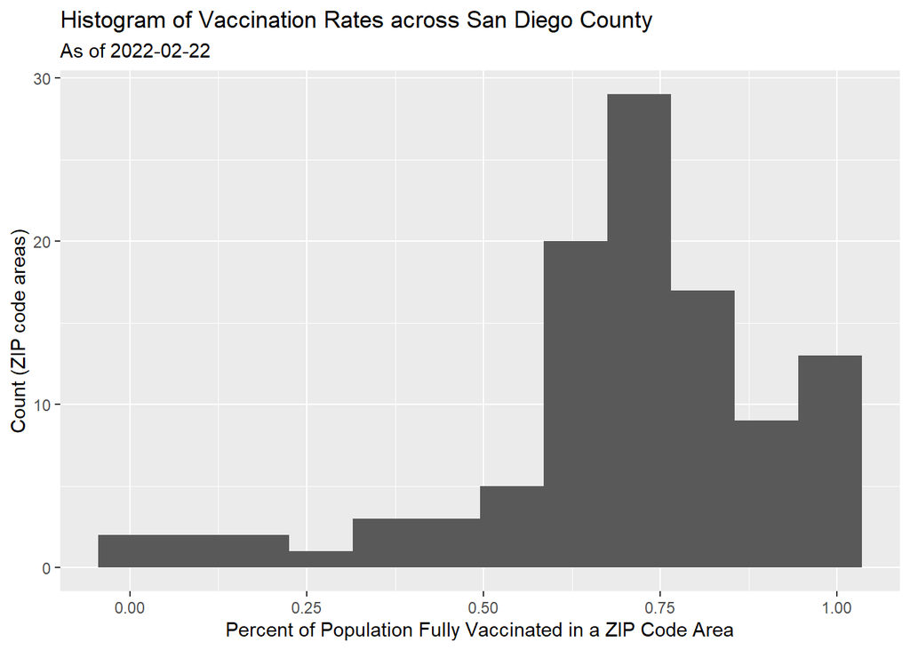

```r
# use ggplot to make the figure
library(ggplot2)
ggplot(sd.20220222, aes(x = percent_of_population_fully_vaccinated)) +
  geom_histogram(bins = 12) +
  labs(title = "Histogram of Vaccination Rates across San Diego County", subtitle = "As of 2022-02-22", x = "Percent of Population Fully Vaccinated in a ZIP Code Area", y = "Count (ZIP code areas)")
```

## Focus on UCSD/La Jolla

```r
# define selection on ucsd/la jolla area by zip code 92037 and verify population
ucsd <- filter(sd, zip_code_tabulation_area=="92037")
ucsd[1,]$age5_plus_population
```

```
## [1] 36144
```

### Q15. Using ggplot make a graph of the vaccination rate time course for the 92037 ZIP code area:

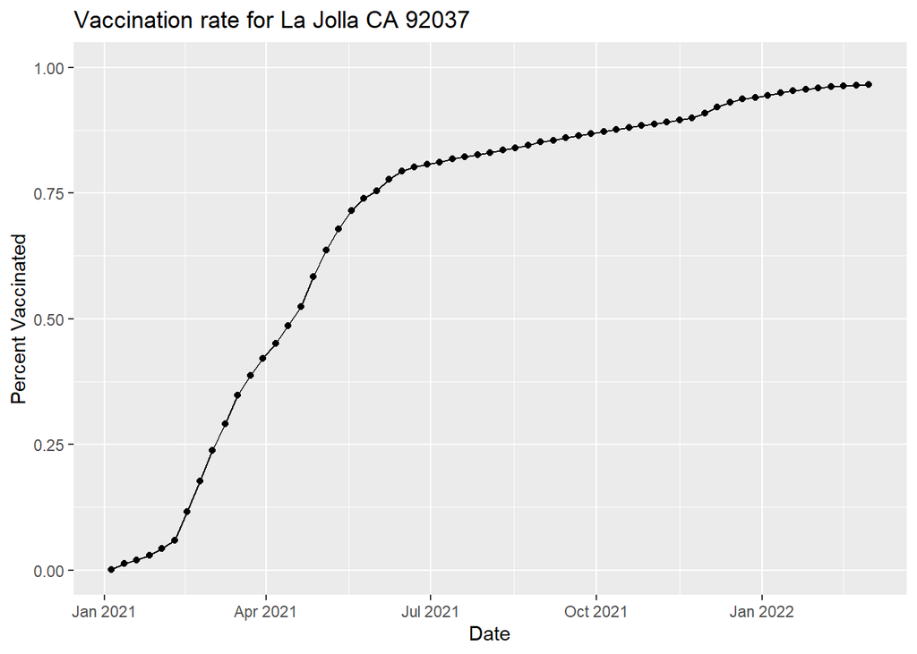

```r
ggplot(ucsd) +
  aes(x = as_of_date,
      y = percent_of_population_fully_vaccinated) +
  geom_point() +
  geom_line(group=1) +
  ylim(c(0,1)) +
  labs(x = "Date", y="Percent Vaccinated", title = "Vaccination rate for La Jolla CA 92037")
```

## Comparing to similar sized areas

```r
# Subset to all CA areas with a population as large as 92037
vax.36 <- filter(vax, age5_plus_population > 36144 &
                as_of_date == "2022-02-22")

head(vax.36)
```

```
##   as_of_date zip_code_tabulation_area local_health_jurisdiction      county
## 1 2022-02-22                    92840                    Orange      Orange
## 2 2022-02-22                    92064                 San Diego   San Diego
## 3 2022-02-22                    92508                 Riverside   Riverside
## 4 2022-02-22                    95403                    Sonoma      Sonoma
## 5 2022-02-22                    90001               Los Angeles Los Angeles
## 6 2022-02-22                    92802                    Orange      Orange
##   vaccine_equity_metric_quartile                 vem_source
## 1                              2 Healthy Places Index Score
## 2                              4 Healthy Places Index Score
## 3                              3 Healthy Places Index Score
## 4                              3 Healthy Places Index Score
## 5                              1 Healthy Places Index Score
## 6                              2 Healthy Places Index Score
##   age12_plus_population age5_plus_population persons_fully_vaccinated
```

[output cut: 27 more lines]

### Q16. Calculate the mean “Percent of Population Fully Vaccinated” for ZIP code areas with a population as large as 92037 (La Jolla) as_of_date “2022-02-22”. Add this as a straight horizontal line to your plot from above with the geom_hline() function?

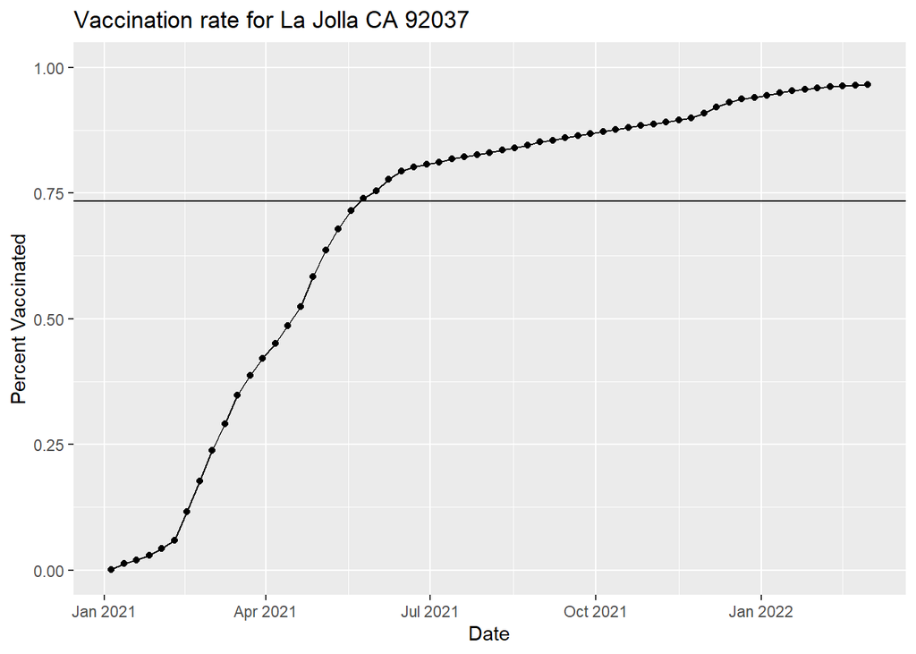

```r
# find mean vaccination rate
ca.mean <- mean(vax.36$percent_of_population_fully_vaccinated, na.rm = TRUE)

# add this as a straight horizontal line to plot
ggplot(ucsd) +
  aes(x = as_of_date,
      y = percent_of_population_fully_vaccinated) +
  geom_point() +
  geom_line(group=1) +
  ylim(c(0,1)) +
  labs(x = "Date", y="Percent Vaccinated", title = "Vaccination rate for La Jolla CA 92037") +
  geom_hline(aes(yintercept=ca.mean))
```

### Q17. What is the 6 number summary (Min, 1st Qu., Median, Mean, 3rd Qu., and Max) of the “Percent of Population Fully Vaccinated” values for ZIP code areas with a population as large as 92037 (La Jolla) as_of_date “2022-02-22”?

```r
fivenum(vax.36$percent_of_population_fully_vaccinated)
```

```
## [1] 0.3881090 0.6539015 0.7332750 0.8027110 1.0000000
```

```r
mean(vax.36$percent_of_population_fully_vaccinated)
```

```
## [1] 0.733385
```

Min: 0.3881090 1st Qu.: 0.6539015 Median: 0.7332750 Mean: 0.733385 3rd Qu.: 0.8027110 Max: 1.0000000

### Q18. Using ggplot generate a histogram of this data.

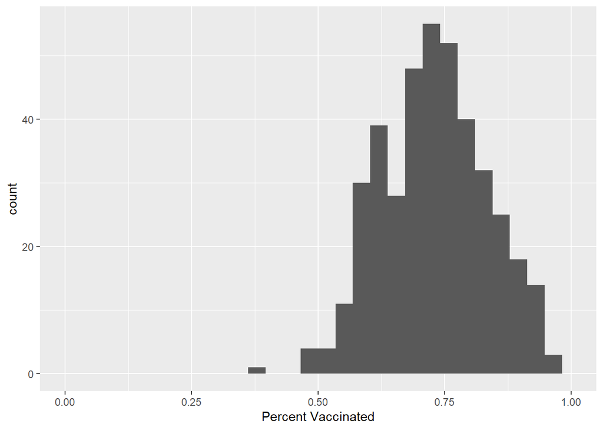

```r
ggplot(vax.36, aes(x = percent_of_population_fully_vaccinated)) +
  geom_histogram() +
  labs(x = "Percent Vaccinated") +
  xlim(0, 1)
```

### Q19. Is the 92109 and 92040 ZIP code areas above or below the average value you calculated for all these above?

```r
# for 92040
vax %>% filter(as_of_date == "2022-02-22") %>%
  filter(zip_code_tabulation_area=="92040") %>%
  select(percent_of_population_fully_vaccinated)
```

```
##   percent_of_population_fully_vaccinated
## 1                               0.551304
```

```r
# for 92109
vax %>% filter(as_of_date == "2022-02-22") %>%
  filter(zip_code_tabulation_area=="92109") %>%
  select(percent_of_population_fully_vaccinated)
```

```
##   percent_of_population_fully_vaccinated
## 1                               0.723044
```

Both are below the average vlaue calculated earlier (0.55 < 0.73, 0.72 < 0.73).

### Q20. Finally make a time course plot of vaccination progress for all areas in the full dataset with a age5_plus_population > 36144.

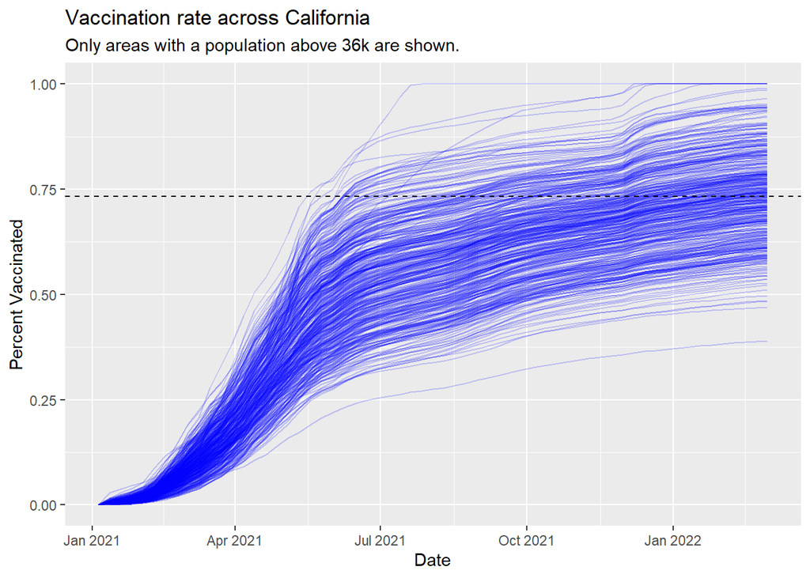

```r
vax.36.all <- filter(vax, age5_plus_population > 36144)


ggplot(vax.36.all) +
  aes(x = as_of_date,
      percent_of_population_fully_vaccinated,
      group=zip_code_tabulation_area) +
  geom_line(alpha=0.2, color="blue") +
  ylim(0,1) +
  labs(x="Date", y="Percent Vaccinated",
       title="Vaccination rate across California",
       subtitle="Only areas with a population above 36k are shown.") +
  geom_hline(yintercept = ca.mean, linetype = "dashed")
```

### Q21. How do you feel about traveling for Spring Break and meeting for in-person class afterwards?

I’d generally feel comfortable traveling and meeting in-person in CA afterwards based on current trends in vaccination rates. Some areas might require additional caution as the (full) vaccination rate remained below 50% as of now and show no significant increase in slope.